# chapter-1-fast-dirty-Polarity-scoring

Xiaotian Sun

15/02/2020

## 1. Fast & Dirty: Polarity Ccoring

##### 1.1 Let’s talk about our feelings (video)

- sentiment analysis is the process of extracting an author’s emotional intent from text.

##### 1. 2 Jump right in! Visualize polarity

Sentiment analysis helps you extract an author’s feelings towards a subject. This exercise will give you a taste of what’s to come!

We created `text_df` representing a conversation with `person` and `text` columns.

Use `qdap`’s `polarity()` function to score `text_df`. `polarity()` will accept a single character object or data frame with a grouping variable to calculate a positive or negative score.

In this example you will use the `magrittr` package’s dollar pipe operator `%$%`. The dollar sign forwards the data frame into `polarity()` and you declare a text column name or the text column and a grouping variable without quotes.

> text_data_frame %$% polarity(text_column_name)

To create an object with the dollar sign operator:

> polarity_object <- text_data_frame %$% polarity(text_column_name, grouping_column_name)

More specifically, to make a quantitative judgement about the sentiment of some text, you need to give it a score. A simple method is a positive or negative value related to a sentence, passage or a collection of documents called a corpus. Scoring with positive or negative values only is called “polarity.” A useful function for extracting polarity scores is `counts()` applied to the polarity object. For a quick visual call `plot()` on the `polarity()` outcome.

*Instruction:*

- Examine the `text_df` conversation data frame.
- Using `%$%` pass `text_df` to `polarity()` along with the column name `text` without quotes. This will print the polarity for all text.
- Create a new object `datacamp_conversation` by forwarding text_df with `%$%` to `polarity()`. Pass in `text` followed by the grouping `person` column. This will calculate polarity according to each individual person. Since it is all within parentheses the result will be printed too.
- Apply `counts()` to `datacamp_conversation` to print the specific emotional words that were found.
- `plot()` the `datacamp_conversation`.

```r
# Examine the text data
text_df
```

```
##     person
## 1     Nick
## 2 Jonathan
## 3  Martijn
## 4   Nicole
## 5     Nick
## 6 Jonathan
## 7  Martijn
## 8   Nicole
##                                                                         text
## 1                                              DataCamp courses are the best
## 2                                                 I like talking to students
## 3                            Other online data science curricula are boring.
## 4                                                         What is for lunch?
## 5                                        DataCamp has lots of great content!
## 6                           Students are passionate and are excited to learn
## 7 Other data science curriculum is hard to learn and difficult to understand
## 8                                             I think the food here is good.
```

```r
# Calc overall polarity score
text_df %$% polarity(text)
```

```
##   all total.sentences total.words ave.polarity sd.polarity stan.mean.polarity
## 1 all               8          54        0.179       0.452              0.396
```

```r
# Calc polarity score by person
(datacamp_conversation <- text_df %$% polarity(text, person))
```

```
##     person total.sentences total.words ave.polarity sd.polarity stan.mean.polarity
## 1 Jonathan               2          13        0.577       0.184              3.141
## 2  Martijn               2          19       -0.478       0.141             -3.388
## 3     Nick               2          11        0.428       0.028             15.524
## 4   Nicole               2          11        0.189       0.267              0.707
```

```r
# Counts table from datacamp_conversation
counts(datacamp_conversation)
```

```
##     person wc polarity           pos.words       neg.words                                                                   text.var
## 1     Nick  5    0.447                best               -                                              DataCamp courses are the best
## 2 Jonathan  5    0.447                like               -                                                 I like talking to students
## 3  Martijn  7   -0.378                   -          boring                            Other online data science curricula are boring.
## 4   Nicole  4    0.000                   -               -                                                         What is for lunch?
## 5     Nick  6    0.408               great               -                                        DataCamp has lots of great content!
## 6 Jonathan  8    0.707 passionate, excited               -                           Students are passionate and are excited to learn
## 7  Martijn 12   -0.577                   - hard, difficult Other data science curriculum is hard to learn and difficult to understand
## 8   Nicole  7    0.378                good               -                                             I think the food here is good.
```

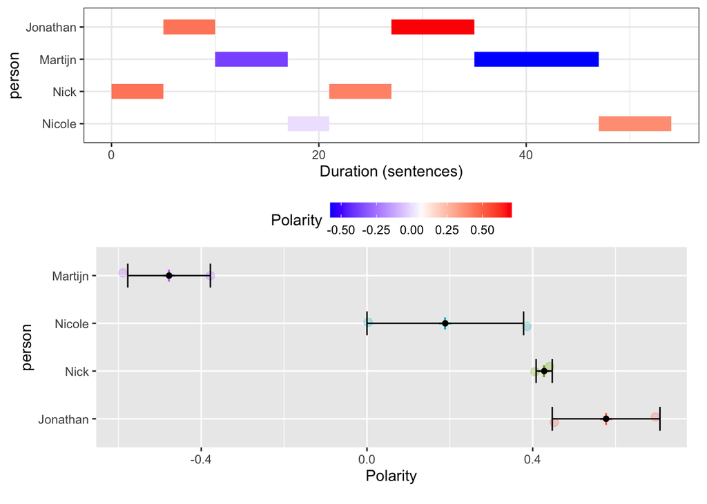

```r
# Plot the conversation polarity
plot(datacamp_conversation)
```

##### 1.3 TM refresher (I)

In the `Text Mining: Bag of Words` course you learned that a corpus is a set of texts, and you studied some functions for preprocessing the text. To recap, one way to create & clean a corpus is with the functions below. Even though this is a different course, sentiment analysis is part of text mining so a refresher can be helpful.

- Turn a character vector into a text source using `VectorSource()`.
- Turn a text source into a corpus using `VCorpus()`.
- Remove unwanted characters from the corpus using cleaning functions like `removePunctuation()` and `stripWhitespace()` from `tm`, and `replace_abbreviation()` from qdap.

In this exercise a custom `clean_corpus()` function has been created using standard preprocessing functions for easier application.

`clean_corpus()` accepts the output of `VCorpus()` and applies cleaning functions. For example:

> processed_corpus <- clean_corpus(my_corpus)

*Instruction:*

Your R session has a text vector, `tm_define`, containing two small documents and the function `clean_corpus()`.

- Create an object called `tm_vector` by applying `VectorSource()` to `tm_define`.
- Make `tm_corpus` using `VCorpus()` on tm_vector.
- Use `content()` to examine the contents of the first document in `tm_corpus`.
  - Documents in the corpus are accessed using list syntax, so use double square brackets, e.g. `[[1]]`.
- Clean the corpus text using the custom function `clean_corpus()` on `tm_corpus`. Call this new object `tm_clean`.
- Examine the first document of the new `tm_clean` object again to see how the text changed after `clean_corpus()` was applied.

```r
# clean_corpus(), tm_define are pre-defined
clean_corpus
```

```
## function(corpus){
##   corpus <- tm_map(corpus, content_transformer(replace_abbreviation))
##   corpus <- tm_map(corpus, removePunctuation)
##   corpus <- tm_map(corpus, removeNumbers)
##   corpus <- tm_map(corpus, removeWords, c(stopwords("en"), "coffee"))
##   corpus <- tm_map(corpus, content_transformer(tolower))
##   corpus <- tm_map(corpus, stripWhitespace)
##   return(corpus)
## }
```

```r
tm_define
```

```
## [1] "Text mining is the process of distilling actionable insights from text."
## [2] "Sentiment analysis represents the set of tools to extract an author's feelings towards a subject."
```

```r
# Create a VectorSource
tm_vector <- VectorSource(tm_define)

# Apply VCorpus
tm_corpus <- VCorpus(tm_vector)

# Examine the first document's contents
content(tm_corpus[[1]])
```

```
## [1] "Text mining is the process of distilling actionable insights from text."
```

```r
# Clean the text
tm_clean <- clean_corpus(tm_corpus)

# Reexamine the contents of the first doc
content(tm_clean[[1]])
```

```
## [1] "text mining process distilling actionable insights text"
```

##### 1.4 TM refresher (II)

Now let’s create a Document Term Matrix (DTM). In a DTM:

- Each row of the matrix represents a document.
- Each column is a unique word token.
- Values of the matrix correspond to an individual document’s word usage.

The DTM is the basis for many bag of words analyses. Later in the course, you will also use the related Term Document Matrix (TDM). This is the transpose; that is, columns represent documents and rows represent unique word tokens.

You should construct a DTM after cleaning the corpus (using `clean_corpus()`). To do so, call `DocumentTermMatrix()` on the corpus object.

> tm_dtm <- DocumentTermMatrix(tm_clean)

If you need a more in-depth refresher check out the `Text Mining: Bag of Words` course. Hopefully these two exercises have prepared you well enough to embark on your sentiment analysis journey!

Be aware that this is real data from Twitter and as such there is always a risk that it may contain profanity or other offensive content (in this exercise, and any following exercises that also use real Twitter data).

*Instruction:*

We’ve created a `VCorpus()` object called `clean_text` containing 1000 tweets mentioning coffee. The tweets have been cleaned with the previously mentioned preprocessing steps and your goal is to create a DTM from it.

```r
# clean_text is pre-defined
clean_text
```

```
## <<VCorpus>>
## Metadata:  corpus specific: 0, document level (indexed): 0
## Content:  documents: 1000
```

```r
# Create tf_dtm
tf_dtm <- DocumentTermMatrix(clean_text)

# Create tf_dtm_m
tf_dtm_m <- as.matrix(tf_dtm)

# Dimensions of DTM matrix
dim(tf_dtm_m)
```

```
## [1] 1000 3098
```

```r
# Subset part of tf_dtm_m for comparison
tf_dtm_m[16:20, 2975:2985]
```

```
##     Terms
## Docs went were west westin westside wet wfriends what whatever
##   16    0    0    0      0        0   0        0    0        0
##   17    0    0    0      0        0   0        0    0        0
##   18    0    0    0      0        0   0        0    0        0
##   19    0    0    0      0        0   0        0    0        0
##   20    0    0    0      0        0   0        0    0        0
##     Terms
## Docs whatislifeee whats
##   16            0     0
##   17            0     0
##   18            0     0
##   19            0     0
##   20            0     0
```

##### 1.5 How many words do YOU know? Zipf’s law & subjectivity lexicon (video)

**Subjectivity lexicon**

A subjectivity lexicon is a predefined list of words associated with emotional context suck as positive/negative, or specific emotions like “frustration” or “joy”.

##### 1.6 What is a subjectivity lexicon?

##### 1.7 Where can you observe Zipf’s law?

Although Zipf observed a steep and predictable decline in word usage you may not buy into Zipf’s law. You may be thinking “I know plenty of words, and have a distinctive vocabulary”. That may be the case, but the same can’t be said for most people! To prove it, let’s construct a visual from 3 million tweets mentioning “#sb”. Keep in mind that the visual doesn’t follow Zipf’s law perfectly, the tweets all mentioned the same hashtag so it is a bit skewed. That said, the visual you will make follows a steep decline showing a small lexical diversity among the millions of tweets. So there is some science behind using lexicons for natural language analysis!

In this exercise, you will use the package `metricsgraphics`. Although the author suggests using the pipe `%>%` operator, you will construct the graphic step-by-step to learn about the various aspects of the plot. The main function of the package `metricsgraphics` is the `mjs_plot()` function which is the first step in creating a JavaScript plot. Once you have that, you can add other layers on top of the plot.

An example `metricsgraphics` workflow without using the `%>%` operator is below:

> metro_plot <- mjs_plot(data, x = x_axis_name, y = y_axis_name, show_rollover_text = FALSE) metro_plot <- mjs_line(metro_plot) metro_plot <- mjs_add_line(metro_plot, line_one_values) metro_plot <- mjs_add_legend(metro_plot, legend = c(‘names’, ‘more_names’)) metro_plot

*Instruction:*

- Use `head()` on `sb_words` to review top words.
- Create a new column `expectations` by dividing the largest word frequency, `freq[1]`, by the `rank` column.
- Start `sb_plot` using `mjs_plot()`.
  - Pass in `sb_words` with `x = rank` and `y = freq`.
  - Within `mjs_plot()` set `show_rollover_text` to `FALSE`.
- Overwrite sb_plot using `mjs_line()` and pass in `sb_plot`.
- Add to sb_plot with `mjs_add_line()`.
  - Pass in the previous `sb_plot` object and the vector, `expectations`.
- Place a legend on a new `sb_plot` object using `mjs_add_legend()`.
  - Pass in the previous `sb_plot` object
  - The legend labels should consist of `"Frequency"` and `"Expectation"`.
- Call `sb_plot` to display the plot. Mouseover a point to simultaneously highlight a `freq` and `Expectation` point. The magic of JavaScript!

```r
# Examine sb_words
head(sb_words)
```

```
##   word    freq rank
## 1   sb 1984423    1
## 2   rt 1700564    2
## 3  the 1101899    3
## 4   to  588803    4
## 5    a  428598    5
## 6  for  388390    6
```

```r
# Create expectations
sb_words$expectations <- sb_words %$%
  {freq[1] / rank}

# Create metrics plot
sb_plot <- mjs_plot(sb_words, x = rank, y = freq, show_rollover_text = FALSE)

# Add 1st line
sb_plot <- mjs_line(sb_plot)

# Add 2nd line
sb_plot <- mjs_add_line(sb_plot, expectations)

# Add legend
sb_plot <- mjs_add_legend(sb_plot, legend = c("Frequency", "Expectation"))

# Display plot
sb_plot
```

[interactive chart not shown]

##### 1.8 Polarity on actual text

So far you have learned the basic components needed for assessing positive or negative intent in text. Remember the following points so you can feel confident in your results.

- The `subjectivity lexicon` is a predefined list of words associated with emotions or positive/negative feelings.
- You don’t have to list every word in a subjectivity lexicon because `Zipf's law` describes human expression.

A quick way to get started is to use the `polarity()` function which has a built-in subjectivity lexicon.

The function scans the text to identify words in the lexicon. It then creates a cluster around an identified subjectivity word. Within the cluster valence shifters adjust the score. Valence shifters are words that amplify or negate the emotional intent of the subjectivity word. For example, “well known” is positive while “not well known” is negative. Here “not” is a negating term and reverses the emotional intent of “well known.” In contrast, “very well known” employs an amplifier increasing the positive intent.

The `polarity()` function then calculates a score using subjectivity terms, valence shifters and the total number of words in the passage. This exercise demonstrates a simple polarity calculation. In the next video we look under the hood of `polarity()` for more detail.

*Instruction 1:*

Calculate the `polarity()` of `positive` in a new object called `pos_score`. Encase the entire call in parentheses so the output is also printed.

```r
# Example statement
positive <- "DataCamp courses are good for learning"

# Calculate polarity of statement
(pos_score <-polarity(positive))
```

```
##   all total.sentences total.words ave.polarity sd.polarity stan.mean.polarity
## 1 all               1           6        0.408          NA                 NA
```

*Instruction 2:*

Manually perform the same polarity calculation.

- Get a word count object by calling `counts()` on the polarity object.
- All the identified subjectivity words are part of count object’s list. Specifically, positive words are in `$pos.words` element vector. Find the number of positive words in `n_good` by calling `length()` on the first part of the `$pos.words` element.
- Capture the total number of words and assign it to n_words. This value is stored in pos_count as the wc element.
- De-construct the `polarity()` calculation by dividing `n_good` by `sqrt()` of `n_words`. Compare the result to `pos_pol` to the equation’s result.

```r
# Get counts
(pos_counts <- counts(pos_score))
```

```
##   all wc polarity pos.words neg.words                               text.var
## 1 all  6    0.408      good         - DataCamp courses are good for learning
```

```r
# Number of positive words
n_good <- length(pos_counts$pos.words[[1]])

# Total number of words
n_words <- pos_counts$wc

# Verify polarity score
n_good / sqrt(n_words)
```

```
## [1] 0.4082483
```

##### 1.9 Explore qdap’s polarity & built-in lexicon (video)

##### 1.10 Happy songs!

Of course just positive and negative words aren’t enough. In this exercise you will learn about valence shifters which tell you about the author’s emotional intent. Previously you applied `polarity()` to text without valence shifters. In this example you will see amplification and negation words in action.

Recall that an **amplifying** word adds 0.8 to a positive word in `polarity()` so the positive score becomes 1.8. For negative words 0.8 is subtracted so the total becomes -1.8. Then the score is divided by the square root of the total number of words.

Consider the following example from Frank Sinatra:

- “It was a very good year”

“Good” equals 1 and “very” adds another 0.8. So, 1.8/sqrt(6) results in 0.73 polarity.

A **negating** word such as “not” will inverse the subjectivity score. Consider the following example from Bobby McFerrin:

- “Don’t worry Be Happy”

“worry is now 1 due to the negation”don’t." Adding the “happy”, +1, equals 2. With 4 total words, `2 / sqrt(4)` equals a polarity score of 1.

*Instruction:*

- Examine the conversation data frame,`conversation`. Note the valence shifters like “never” in the text column.
- Apply `polarity()` to the text column of conversation to calculate polarity for the entire conversation.
- Calculate the polarity scores by student, assigning the result to `student_pol`.
  - Call `polarity()` again, this time passing two columns of conversation.
  - The text variable is `text` and the grouping variable is `student.`
- To see the student level results, use `scores()` on `student_pol`.
- The `counts()` function applied to `student_pol` will print the sentence level polarity for the entire data frame along with lexicon words identified.
- The polarity object, `student_pol`, can be plotted with `plot()`.

```r
# Examine conversation
conversation
```

```
##                                 student
## 1   Martijn
## 2 Nick
## 3                               Nicole
##                                                      text
## 1                            This restaurant is never bad
## 2                                 The lunch was very good
## 3 It was awful I got food poisoning and was extremely ill
```

```r
# Polarity - All
polarity(conversation$text)
```

```
##   all total.sentences total.words ave.polarity sd.polarity stan.mean.polarity
## 1 all               3          21        0.317       0.565              0.561
```

```r
# Polarity - Grouped
student_pol <- conversation %$%
  polarity(text, student)

# Student results
scores(student_pol)
```

```
##                                 student total.sentences total.words ave.polarity sd.polarity stan.mean.polarity
## 1   Martijn                                           1           5        0.447          NA                 NA
## 2 Nick                                                1           5        0.805          NA                 NA
## 3                               Nicole                1          11       -0.302          NA                 NA
```

```r
# Sentence by sentence
counts(student_pol)
```

```
##                                 student wc polarity pos.words neg.words                                                text.var
## 1   Martijn                              5    0.447         -       bad                            This restaurant is never bad
## 2 Nick                                   5    0.805      good         -                                 The lunch was very good
## 3                               Nicole  11   -0.302         -     awful It was awful I got food poisoning and was extremely ill
```

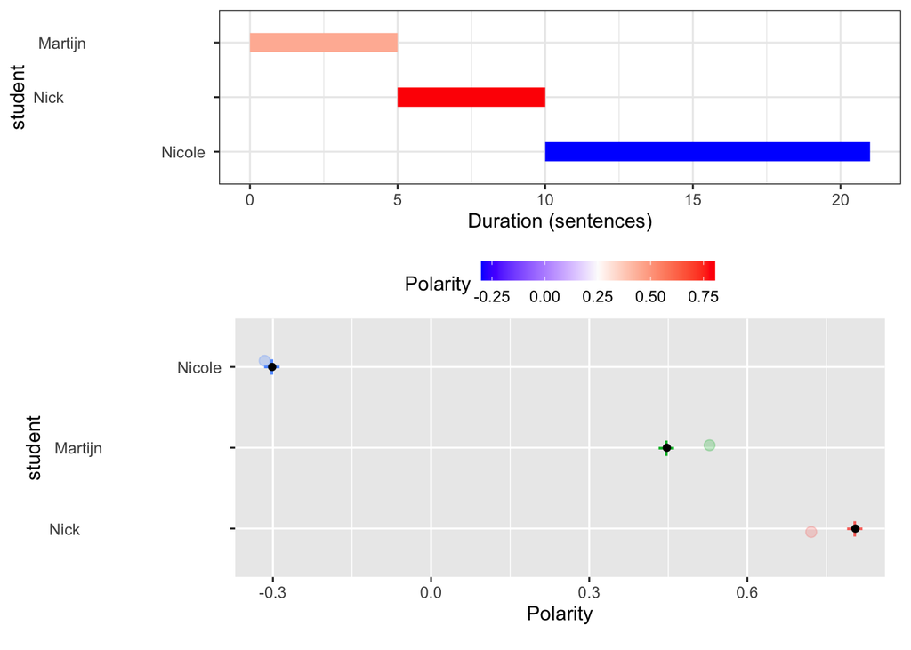

```r
# qdap plot
plot(student_pol)
```

##### 1.11 LOL, this song is wicked good

Even with Zipf’s law in action, you will still need to adjust lexicons to fit the text source (for example twitter versus legal documents) or the author’s demographics (teenager versus the elderly). This exercise demonstrates the explicit components of `polarity()` so you can change it if needed.

In Trey Songz “Lol :)” song there is a lyric “LOL smiley face, LOL smiley face.” In the basic `polarity()` function, “LOL” is not defined as positive. However, “LOL” stands for “Laugh Out Loud” and should be positive. As a result, you should adjust the lexicon to fit the text’s context which includes pop-culture slang. If your analysis contains text from a specific channel (Twitter’s “LOL”), location (Boston’s “Wicked Good”), or age group (teenagers’ “sick”) you will likely have to adjust the lexicon.

In this exercise you are not adjusting the subjectivity lexicon or `qdap` dictionaries containing valence shifters. Instead you are examining the existing word data frame objects so you can change them in the following exercise.

We’ve created `text` containing two excerpts from Beyoncé’s “Crazy in Love” lyrics for the exercise.

*Instruction 1:*

- Print `key.pol` to see a portion of the subjectivity words and values.
- Examine the `predefined negation.words` to print all the negating terms.
- Now print the `amplification.words` to see the words that add values to the lexicon.
- Check the `deamplification.words` to print the words that reduce the lexicon values.
- Call `text` to see conversation.

```r
# Examine the key.pol
key.pol
```

[output not shown]

```r
# Negators
negation.words
```

```
##  [1] "ain't"     "aren't"    "can't"     "couldn't"  "didn't"
##  [6] "doesn't"   "don't"     "hasn't"    "isn't"     "mightn't"
## [11] "mustn't"   "neither"   "never"     "no"        "nobody"
## [16] "nor"       "not"       "shan't"    "shouldn't" "wasn't"
## [21] "weren't"   "won't"     "wouldn't"
```

```r
# Amplifiers
amplification.words
```

```
##  [1] "acute"         "acutely"       "certain"       "certainly"
##  [5] "colossal"      "colossally"    "deep"          "deeply"
##  [9] "definite"      "definitely"    "enormous"      "enormously"
## [13] "extreme"       "extremely"     "great"         "greatly"
## [17] "heavily"       "heavy"         "high"          "highly"
## [21] "huge"          "hugely"        "immense"       "immensely"
## [25] "incalculable"  "incalculably"  "massive"       "massively"
## [29] "more"          "particular"    "particularly"  "purpose"
## [33] "purposely"     "quite"         "real"          "really"
## [37] "serious"       "seriously"     "severe"        "severely"
## [41] "significant"   "significantly" "sure"          "surely"
## [45] "true"          "truly"         "vast"          "vastly"
## [49] "very"
```

```r
# De-amplifiers
deamplification.words
```

```
##  [1] "barely"       "faintly"      "few"          "hardly"
##  [5] "little"       "only"         "rarely"       "seldom"
##  [9] "slightly"     "sparsely"     "sporadically" "very few"
## [13] "very little"
```

```r
# Examine
text
```

[output not shown]

*Instruction 2:*

- Calculate polarity() as follows.
  - Set text.var to text$words.
  - Set grouping.var to text$speaker.
  - Set polarity.frame to key.pol.
  - Set negators to negation.words.
  - Set amplifiers to amplification.words.
  - Set deamplifiers to deamplification.words

```r
# Complete the polarity parameters
polarity(
  text.var       = text$words,
  grouping.var   = text$speaker,
  polarity.frame = key.pol,
  negators       = negation.words,
  amplifiers     = amplification.words,
  deamplifiers   = deamplification.words
)
```

[output not shown]

##### 1.12 Stressed Out!

*Instruction:*

```r
# stressed_out has been pre-defined
head(stressed_out)

# Basic lexicon score
polarity(stressed_out)

# Check the subjectivity lexicon
key.pol[grep("stress", x)]

# New lexicon
custom_pol <- sentiment_frame(positive.words, c(negative.words, "stressed", "turn back"))

# Compare new score
polarity(stressed_out, polarity.frame = custom_pol)
```

[output not shown]